# Logistic Regression

BitTiger DS501

Jun 2017

# Machine Learning 101

In Machine Learning, we design a system that can learn from data.

The system usually includes three components:

- **Hypothesis** (Representation)
  - A relationship (pattern) between the input and output values
  - Examples include linear regression, decision trees, graphical models, neural networks, support vector machines, model ensembles and others.
- **Loss** (Evaluation)
  - A measure of the degree of fit
  - Examples include accuracy, prediction and recall, squared error, likelihood, posterior probability, cost, margin and others.
- **Optimization**
  - A search for optimal parameters (minimize the loss)
  - Examples include combinatorial optimization, convex optimization, constrained optimization.

## Hypothesis

In order to do machine learning, we propose a relationship (pattern) between the input and output values. Lets say that this the function

### $y=f(x)$

this is known as the *target function*.

## Cost Functions

The general way machine learning algorithms work is by optimizing a cost function.

### Linear Regression

In the case of linear regression, the cost function we want to optimize is the residual sum of squares, which is as follows:

[figure not shown]

## Linear Regression Example

### Data Preparation

Let's use sklearn to generate some fake data

```python
import numpy as np
from sklearn.datasets import make_regression
```

```python
X, y = make_regression(
    n_samples=5,
    n_features=1,
    n_informative=1,
    bias=10,
    noise=10,
    random_state=0)
```

```python
X, y
```

```
(array([[ 0.97873798],
        [ 2.2408932 ],
        [ 1.76405235],
        [ 1.86755799],
        [ 0.40015721]]),
 array([  47.7695571 ,  133.51062836,   77.41989586,  102.53006841,
          40.17155299]))
```

```python
# We use matplotlib for plotting
import matplotlib.pyplot as plt

# This statement allow to display plot without asking to
%matplotlib inline

# Always make it pretty.
plt.style.use('ggplot')
```

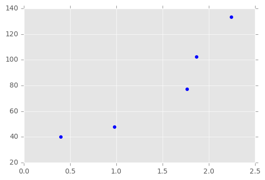

```python
plt.scatter(X, y, color="blue");
```

```python
def hypothesis_linreg(X, coeffs):
    '''
    INPUT: 2 dimensional numpy array, numpy array
    OUTPUT: numpy array

    Calculate the hypothesis for the given data with the given coefficients.
    '''
    return np.dot(X, coeffs)
```

```python
def cost_linreg(X, y, coeffs):
    '''
    INPUT: 2 dimensional numpy array, numpy array
    OUTPUT: numpy array

    Calculate the cost for the given data with the given coefficients.
    '''
    y_pred = hypothesis_linreg(X, coeffs)
    return np.sum((y - y_pred)**2)
```

```python
# Guess a coefficient
coeffs = y.mean() / X.mean()
```

```python
# Calculate the prediction
y_pred = hypothesis_linreg(X, coeffs)
```

```python
print "X: ", X
print "y: ", y
print "y_pred: ", y_pred
print "RSS: ", cost_linreg(X, y, coeffs)
```

```
X:  [[ 0.97873798]
 [ 2.2408932 ]
 [ 1.76405235]
 [ 1.86755799]
 [ 0.40015721]]
y:  [  47.7695571   133.51062836   77.41989586  102.53006841   40.17155299]
y_pred:  [[  54.17811213]
 [ 124.04480564]
 [  97.64924561]
 [ 103.37880805]
 [  22.1507313 ]]
RSS:  64066.4311107
```

```python
def plot_regression_1d_data(X, y, y_pred, ax):
    """Add a scatter plot of data to an axis.

    Parameters
    ----------
    X: ndarray, shape (n_samples, )
    y: ndarray, shape (n_samples, )
    ax: matplotlib axis object
    """
    ax.scatter(X, y, color="blue")
    ax.plot(X, y_pred, color="red")
    ax.set_xlabel("$X$")
    ax.set_ylabel("$y$")
```

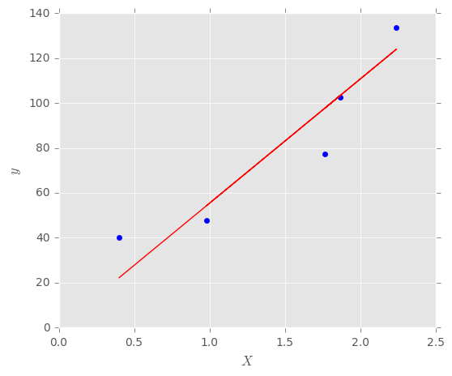

```python
fig, ax = plt.subplots(1, figsize=(6, 5))
plot_regression_1d_data(X, y, y_pred, ax)
```

### Closed Form solution of Linear Regression

We're lucky in the case of linear regression that there is what we call a *closed form*. This is an equation we can use to directly find the optimal beta coefficients. For linear regression, we call this equation the Normal Equation:

[figure not shown]

```python
# Solve for coefficients
coeffs = np.dot(np.dot(np.linalg.inv(np.dot(X.T, X)), X.T),y)
coeffs
```

```
array([ 54.16819984])
```

```python
# This is equivalent:
coeffs = np.linalg.inv(X.T.dot(X)).dot(X.T).dot(y)
coeffs
```

```
array([ 54.16819984])
```

```python
# Calculate the prediction
y_pred = hypothesis_linreg(X, coeffs)
```

```python
print "X: ", X
print "y: ", y
print "y_pred: ", y_pred
print "RSS: ", cost_linreg(X, y, coeffs)
```

```
X:  [[ 0.97873798]
 [ 2.2408932 ]
 [ 1.76405235]
 [ 1.86755799]
 [ 0.40015721]]
y:  [  47.7695571   133.51062836   77.41989586  102.53006841   40.17155299]
y_pred:  [  53.01647471  121.38515063   95.55554     101.16225442   21.67579563]
RSS:  847.422898317
```

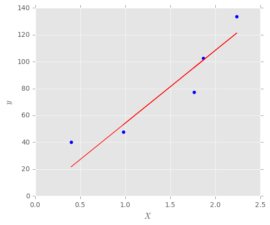

```python
fig, ax = plt.subplots(1, figsize=(6, 5))

plot_regression_1d_data(X, y, y_pred, ax)
```

### Fit the intercept/bias

```python
def add_intercept(X):
    '''
    INPUT: 2 dimensional numpy array
    OUTPUT: 2 dimensional numpy array

    Return a new 2d array with a column of ones added as the first
    column of X.
    '''
    return np.hstack((np.ones((X.shape[0], 1)), X))
```

```python
print X
print add_intercept(X)
```

```
[[ 0.97873798]
 [ 2.2408932 ]
 [ 1.76405235]
 [ 1.86755799]
 [ 0.40015721]]
[[ 1.          0.97873798]
 [ 1.          2.2408932 ]
 [ 1.          1.76405235]
 [ 1.          1.86755799]
 [ 1.          0.40015721]]
```

```python
X_ = add_intercept(X)
```

```python
# Solve for coefficients
coeffs_ = np.dot(np.dot(np.linalg.inv(np.dot(X_.T, X_)), X_.T),y)
coeffs_
```

```
array([  9.86530739,  48.55272465])
```

```python
# Calculate the prediction
y_pred = hypothesis_linreg(X_, coeffs_)
```

```python
print "X: ", X_
print "y: ", y
print "y_pred: ", y_pred
print "RSS: ", cost_linreg(X_, y, coeffs_)
```

```
X:  [[ 1.          0.97873798]
 [ 1.          2.2408932 ]
 [ 1.          1.76405235]
 [ 1.          1.86755799]
 [ 1.          0.40015721]]
y:  [  47.7695571   133.51062836   77.41989586  102.53006841   40.17155299]
y_pred:  [  57.38570324  118.66677786   95.51485522  100.54033626   29.29403015]
RSS:  762.517255292
```

**Result**: Compared with previous model, model with intercept gives lower RSS

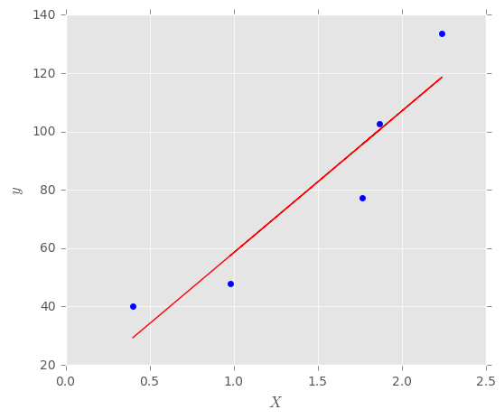

```python
fig, ax = plt.subplots(1, figsize=(6, 5))

plot_regression_1d_data(X, y, y_pred, ax)
```

# Classification

### Data preparation

Generate a dataset using sklearn's make_classification module. We use two features so that we can visualize our data.

```python
from sklearn.datasets import make_classification
X, y = make_classification(
    n_samples=100,
    n_features=2,
    n_informative=2,
    n_redundant=0,
    n_classes=2,
    random_state=0)
```

### Visualize the data

Make a scatterplot with the first feature on the x axis and the second on the y axis. Differentiate the positive results from the negative results somehow (different colors or different symbols).

We choose to differentiate the two classes with different colored data points. It is important, when choosing colors, to be aware of colorblind consumers. Red and blue are good choices.

```python
def plot_classification_data(X, y, ax):
    """Add a scatter plot of data to an axis.

    Parameters
    ----------
    X: ndarray, shape (n_samples, 2)
    y: ndarray, shape (n_samples, )
    ax: matplotlib axis object
    """
    colors = np.array(["red", "blue"])[y]
    ax.scatter(X[:, 0], X[:, 1], color=colors)
    ax.set_xlabel("$x_0$")
    ax.set_ylabel("$x_1$")
```

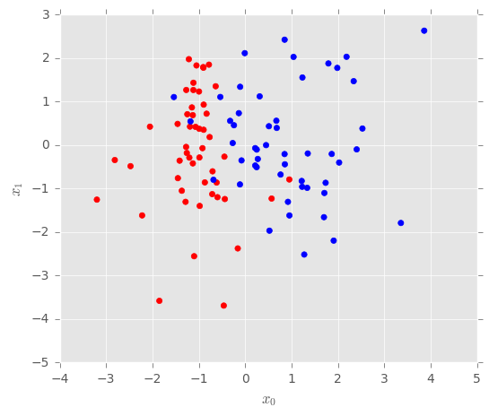

```python
fig, ax = plt.subplots(1, figsize=(6, 5))

plot_classification_data(X, y, ax)
```

### Eyb-balling the decision boundary

Just by eye-balling, make an estimate for a good coefficient for this equation: `y = mx` of the decision boundary. We are using this form since our first implementation will not find an intercept. But also make an estimate for good coefficients for this equation: `y = mx+b`

It looks like a decent decision boundary for this data (given that it is of the form `y = mx`) would pass through the data points $(0, 0)$ and $(-1, 1.5)$. This gives the slope `m` from the following simple calculation:

$$ m = \frac{1.5 - 0}{-1 - 0} = \frac{1.5}{-1} = -1.5 $$

Let's superimpose this line on the above plot above.

```python
def compute_scatterplot_bounds(X):
    """Compute the axis bounds for a scatterplot from a two column matrix of data.

    Parameters
    ----------
    X: ndarray, shape (n_samples, 2)
    """
    x0_bounds = (X[:, 0].min(), X[:, 0].max())
    x1_bounds = (X[:, 1].min(), X[:, 1].max())
    return x0_bounds, x1_bounds

def set_scatterplot_bounds(x0_bounds, x1_bounds, ax):
    """Set the axis bounds on a matplotlib axis.

    Parameters
    ----------
    x0_bounds: tuple with two elements.  The bounds on the first axis.
    x1_bounds: tuple with two elements.  The bounds on the second axis.
    ax: matplotlib axis object
    """
    ax.set_xlim(x0_bounds)
    ax.set_ylim(x1_bounds)
```

```python
def plot_eyeballed_line_no_intercept(X, ax):
    """Add the zero intercept line we eyeballed above to the scatterplot."""
    x0_bounds, x1_bounds = compute_scatterplot_bounds(X)
    t = np.linspace(x0_bounds[0], x0_bounds[1], num=3)
    ax.plot(t, -1.5*t, linestyle='--', label="Eyeballed Line")
    set_scatterplot_bounds(x0_bounds, x1_bounds, ax)
```

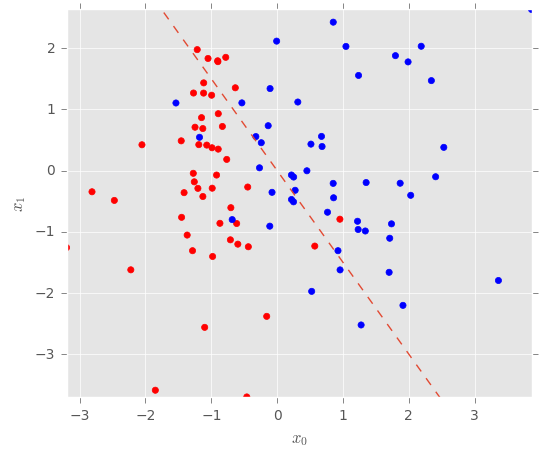

```python
fig, ax = plt.subplots(1, figsize=(6, 5))

plot_classification_data(X, y, ax)
plot_eyeballed_line_no_intercept(X, ax)
```

That looks alright for an eyballed line.

We can also eyeball a line with an intercept. Let's look at a line that goes through the points $(1, -4)$ and $(-1, 2)$.

So:

$$ m = \frac{2 - (-4)}{-1 - 1} = -\frac{6}{2} = -3 $$

Solving for the intercept:

$$ 2 = (-3) \times (-1) + b \Rightarrow b = 2 - 3 = -1 $$

So alltogether out eyeballed line is:

$$ y = -3 x -1 $$

```python
def plot_eyeballed_line(X, ax):
    """Add the line we eyeballed above to the scatterplot."""
    x0_bounds, x1_bounds = compute_scatterplot_bounds(X)
    t = np.linspace(x0_bounds[0], x0_bounds[1], num=3)
    ax.plot(t, -3*t - 1, linestyle='--', label="Eyeballed Line")
    set_scatterplot_bounds(x0_bounds, x1_bounds, ax)
```

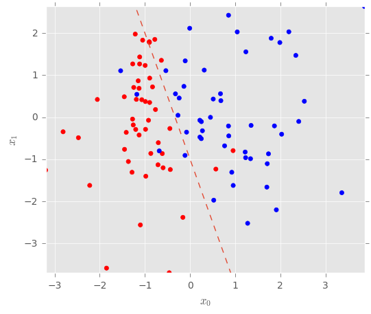

```python
fig, ax = plt.subplots(1, figsize=(6, 5))

plot_classification_data(X, y, ax)
plot_eyeballed_line(X, ax)
```

This looks pretty ok for an eyeball estimate, but we can surely do better. Thankfully, we have **machine learning**!

## Logistic Regression

With Logistic Regression we will be *maximizing* the likelihood function (instead of minimizing a cost function).

The likelihood is going to be a value from 0 to 1 that is created based on the idea of being probability of our chosen coefficients making the perfect model.

### Hypothesis Function

Let's start by looking at our hypothesis function. First recall the sigmoid function:

[figure not shown]

And here's our hypothesis function. This gives us a value from 0 to 1, which is our predicted probability that the datapoint belongs to the positive class.

[figure not shown]

```python
def predict_proba(X, coeffs):
    '''
    INPUT: 2 dimensional numpy array, numpy array
    OUTPUT: numpy array

    Calculate the predicted percentages (floats between 0 and 1) for the given
    data with the given coefficients.
    '''
    linear_predictor = np.dot(X, coeffs)
    return 1.0 / (1 + np.exp(-linear_predictor))
```

```python
def predict(X, coeffs, thres=0.5):
    '''
    INPUT: 2 dimensional numpy array, numpy array
    OUTPUT: numpy array

    Calculate the predicted values (0 or 1) for the given data with the given
    coefficients.
    '''
    probs = predict_proba(X, coeffs)
    return (probs >= thres).astype(int)
```

### Likelihood

First we calculate the probability that a given data point is predicted correctly.

[figure not shown]

We can rewrite this as follows. Take a moment to convince yourself that this is equivalent. Try plugging in both 1 and 0 for y and look at the equation. Note that y is the true value so cannot take on any other values besides 0 and 1.

[figure not shown]

We are going to calculate the *likelihood* that we predict all the datapoints correctly. This is calculated by taking the product of all the individual likelihoods for each data point in our training set.

[figure not shown]

This is essentially the function we're trying to maximize. However, for computational reasons, we will be maximizing the log of this function instead. Maximizing the *log likelihood* is equivalent, but will make computations easier. One issue with calculating small probabilities with a computer is *numerical underflow*. Once the values get sufficiently small, they will be rounded to 0 and we will lose all information.

We use the following two log properties:

[figure not shown]

If we take the log of the likelihood function above, we get the following as our *log likelihood*:

[figure not shown]

```python
def log_likelihood(X, y, coeffs):
    '''
    INPUT: 2 dimensional numpy array, numpy array, numpy array
    OUTPUT: float

    Calculate the log likelihood of the data with the given coefficients.
    '''

    p = predict_proba(X, coeffs)
    cost_per_observation = y * np.log(p) + (1 - y) * np.log(1 - p)
    return np.sum(cost_per_observation)
```

```python
coeffs = np.random.random(X.shape[1])
```

```python
X, y, coeffs
```

```
(array([[ -7.66054695e-01,   1.83324682e-01],
        [ -9.20383253e-01,  -7.23168038e-02],
        [ -9.86585088e-01,  -2.86920000e-01],
        [  1.70910242e+00,  -1.10453952e+00],
        [  1.98764670e+00,   1.77624479e+00],
        [  3.86274219e+00,   2.63325914e+00],
        [ -1.12836011e+00,  -4.22761581e-01],
        [ -1.10074198e+00,  -2.56042975e+00],
        [ -1.53716448e+00,   1.10502647e+00],
        [ -3.23726922e-01,   5.56269743e-01],
        [ -1.28532883e+00,  -1.30819171e+00],
        [  3.35973253e+00,  -1.79506345e+00],
        [ -1.27034986e+00,   1.26780440e+00],
        [ -7.10233633e-01,  -1.13058206e+00],
        [ -1.12933108e+00,   6.87661760e-01],
        [  2.48206729e-01,  -5.09792713e-01],
        [ -2.47263494e+00,  -4.86612462e-01],
        [ -1.11573423e+00,   1.43370121e+00],
        [ -1.21414740e+00,   1.97698901e+00],
        [ -1.25860859e+00,  -1.82896522e-01],
        [ -5.35834091e-01,   1.10698637e+00],
        [  9.23281451e-01,  -1.30813451e+00],
        [  2.02751248e+00,  -4.03257104e-01],
        [  2.18718140e+00,   2.03196825e+00],
        [  5.12814562e-01,   4.32994532e-01],
        [ -2.81180710e+00,  -3.45538051e-01],
        [  3.13380666e-01,   1.12073484e+00],
        [  2.72990606e-01,  -3.21105367e-01],
        [ -1.18986266e+00,   4.24345081e-01],
        [ -1.12132974e-01,  -9.07197428e-01],
        [  1.23567148e+00,   1.55525060e+00],
        [ -7.03291920e-01,  -6.05415797e-01],
        [  1.33828180e+00,  -9.86132567e-01],
        [ -3.19826339e+00,  -1.25732069e+00],
        [  7.64389529e-01,  -6.79598011e-01],
        [  9.52529622e-01,  -7.93470192e-01],
        [ -4.37933163e-01,  -1.24378126e+00],
        [  2.40620516e+00,  -1.00171129e-01],
        [  6.81520677e-01,   3.93906076e-01],
        [  4.51394467e-01,  -2.47553402e-03],
```

[output cut: 51 more lines]

```
        [  2.17261785e-01,  -4.71824167e-01],
        [  1.35081491e+00,  -1.94643859e-01],
        [ -1.41363563e+00,  -3.59967304e-01],
        [  1.86752028e+00,  -2.05721672e-01],
        [ -9.89449288e-01,   3.73436160e-01],
        [ -8.69385004e-01,  -8.60699619e-01],
        [  2.53026908e+00,   3.80251566e-01],
        [ -4.61220130e-01,  -3.69743600e+00],
        [ -2.05321581e+00,   4.22341441e-01]]),
 array([0, 0, 0, 1, 1, 1, 0, 0, 1, 1, 0, 1, 0, 0, 0, 1, 0, 0, 0, 0, 1, 1, 1,
        1, 1, 0, 1, 1, 0, 1, 1, 0, 1, 0, 1, 0, 0, 1, 1, 1, 0, 1, 0, 1, 0, 1,
        1, 0, 1, 0, 0, 1, 1, 0, 0, 0, 0, 1, 0, 0, 1, 0, 0, 1, 1, 0, 0, 1, 0,
        1, 0, 1, 1, 0, 1, 0, 1, 1, 0, 1, 1, 0, 1, 0, 0, 1, 1, 0, 1, 1, 0, 1,
        1, 0, 1, 0, 0, 1, 0, 0]),
 array([ 0.30372758,  0.48996915]))
```

```python
log_likelihood(X, y, coeffs)
```

```
-58.393233349407488
```

```python
p = predict_proba(X, coeffs)
y_hat = predict(X, coeffs)
cost = log_likelihood(X, y, coeffs)
print("The predicted probability vector is {}".format(str(p)))
print("The predicted class vector is {}".format(str(y_hat)))
print("The cost function at these coefficients is {}".format(str(cost)))
```

```
The predicted probability vector is [ 0.46434848  0.42189994  0.39168496  0.49447804  0.81366586  0.92153854
  0.36589823  0.16954473  0.51862878  0.5434477   0.26281987  0.53517124
  0.55856612  0.31655096  0.49848102  0.4565113   0.27102418  0.58990922
  0.64563196  0.38416953  0.59378666  0.41083381  0.60305913  0.8402258
  0.59095384  0.26437998  0.65572661  0.48140434  0.46170562  0.38259301
  0.75718951  0.37513628  0.48083403  0.16974309  0.47481735  0.47515388
  0.32247369  0.66412919  0.59868729  0.53391982  0.44915148  0.4261242
  0.27191498  0.48525897  0.08950172  0.65114374  0.29977326  0.43359088
  0.737717    0.18707535  0.5458715   0.53744011  0.53897753  0.46993741
  0.57477906  0.52521437  0.49215443  0.47560713  0.64541163  0.39400144
  0.50767637  0.22885251  0.31649062  0.7877305   0.37646794  0.64676632
  0.39929831  0.50615323  0.4750378   0.47721202  0.37575704  0.49131962
  0.80715666  0.35200929  0.81241063  0.66142759  0.5788677   0.52527729
  0.61537423  0.3544479   0.80953888  0.56984048  0.6173912   0.51883586
  0.30691595  0.51071355  0.37791982  0.64081676  0.45079581  0.30846508
  0.28272544  0.45879593  0.57808334  0.35303317  0.6145361   0.47064609
  0.33497417  0.72208429  0.12436649  0.39731052]
The predicted class vector is [0 0 0 0 1 1 0 0 1 1 0 1 1 0 0 0 0 1 1 0 1 0 1 1 1 0 1 0 0 0 1 0 0 0 0 0 0
 1 1 1 0 0 0 0 0 1 0 0 1 0 1 1 1 0 1 1 0 0 1 0 1 0 0 1 0 1 0 1 0 0 0 0 1 0
 1 1 1 1 1 0 1 1 1 1 0 1 0 1 0 0 0 0 1 0 1 0 0 1 0 0]
The cost function at these coefficients is -58.3932333494
```

## Gradient Descent/Ascent

Gradient descent/ascent is an algorithm for solving optimization problems. In gradient descent, we would like to find the solution which minimizes the cost function. In gradient ascent (which is the case of logistic regression), we will be maximizing the likelihood. From this point on we'll just talk about gradient ascent.

The best way to visualize gradient ascent is to view a contour surface with hills. You start at some point. You'd like to find the highest point on the hill but you are blindfolded so you can't see where to go, you can just feel in every direction. Every step you take should be in the direction of the steepest slope up. Mathematically, we can find the slope by taking the *gradient* (this is like the derivative in multiple dimensions).

Here's a high level idea of the algorithm:

```
Gradient Ascent:
    Choose a starting point
    Repeat until incremental increase in likelihood is sufficiently small:
        Take a step in the direction of steepest slope (gradient) upwards
```

For completeness, here's *Gradient Descent*:

```
Gradient Descent:
    Choose a starting point
    Repeat until incremental decrease in cost is sufficiently small:
        Take a step in the direction of steepest slope (gradient) downwards
```

For our specific example of logistic regression, here's what our gradient ascent algorithm will look like:

```
Gradient Ascent
    Initialize your beta coefficients (generally choose 0)
    Repeat until incremental increase in likelihood is sufficiently small:
        beta <- beta + alpha * gradient
```

*alpha* is a parameter in our algorithm, generally called the *step size* or *learning rate*.

### Optimizing the learning rate

When using gradient descent, the choice of the learning rate alpha is important.

- If alpha is too small, it will take a really long time to converge.
- If alpha is too large, we'll actually end up overshooting the optimal value and keep getting further and further away! So in this case it will diverge!

[figure not shown]

### Gradient of the Likelihood

The only bit left is to calculate the gradient of the likelihood function. Here we'll really see the mathematical advantages of the sigmoid function.

First, let's just calculate the derivative of the sigmoid:

[figure not shown]

It works out really nicely!

To get the gradient, we need to take the partial derivative of the likelihood function for each coefficient ($\beta_j$). Recall that the derivative of the log function $log(z)$ is $1/z$.

[figure not shown]

We can do some rearranging and simplifying.

[figure not shown]

This is what we'll use to update the coefficients in each iteration of gradient descent.

```python
def log_likelihood_gradient(X, y, coeffs):
    '''
    INPUT: 2 dimensional numpy array, numpy array, numpy array
    OUTPUT: numpy array

    Calculate the gradient of the log likelihood at the given value for the
    coeffs. Return an array of the same size as the coeffs array.
    '''
    p = predict_proba(X, coeffs)
    gradient = X.T.dot(y - p)
    return gradient
```

```python
coeffs = np.random.random(X.shape[1])
print coeffs
```

```
[ 0.12541226  0.72518517]
```

```python
p = predict_proba(X, coeffs)
y_hat = predict(X, coeffs)
cost = log_likelihood(X, y, coeffs)
gradient = log_likelihood_gradient(X, y, coeffs)
print("The predicted probability vector is \n{}".format(str(p)))
print("The predicted class vector is \n{}".format(str(y_hat)))
print("The cost function at these coefficients is \n{}".format(str(cost)))
print("The gradient of the cost is \n{}".format(str(gradient)))
```

```
The predicted probability vector is
[ 0.50921688  0.45813068  0.41780272  0.35740311  0.82308377  0.91637136
  0.38981483  0.11974657  0.64761443  0.58971788  0.24789378  0.29309453
  0.68137013  0.28721406  0.58832617  0.41615787  0.34006987  0.71090267
  0.7826904   0.42788666  0.67602637  0.30304301  0.49046087  0.85168175
  0.5934665   0.35360869  0.70099534  0.45050649  0.53954359  0.33806057
  0.78292823  0.37116085  0.36649297  0.21200335  0.40204041  0.3879461
  0.27750052  0.55703196  0.59173101  0.51370036  0.54244684  0.27060341
  0.24232062  0.49991057  0.05553165  0.72284837  0.15858754  0.43770232
  0.82247665  0.18937848  0.63696645  0.57452934  0.48889868  0.54200558
  0.68321664  0.60324898  0.58852478  0.36747062  0.76462625  0.30527609
  0.49381601  0.14849695  0.27969731  0.8323467   0.25800632  0.76638657
  0.45226535  0.48883537  0.53552897  0.56148887  0.4106899   0.39011027
  0.79576316  0.3309855   0.83024425  0.77630367  0.62599975  0.39822373
  0.71128882  0.33939954  0.86596039  0.68533244  0.62011173  0.61865436
  0.3240463   0.44664392  0.20477236  0.76801796  0.43366714  0.20348213
  0.28192636  0.42191608  0.50706351  0.39213892  0.52124311  0.53661466
  0.32449331  0.64407143  0.0607013   0.51219191]
The predicted class vector is
[1 0 0 0 1 1 0 0 1 1 0 0 1 0 1 0 0 1 1 0 1 0 0 1 1 0 1 0 1 0 1 0 0 0 0 0 0
 1 1 1 1 0 0 0 0 1 0 0 1 0 1 1 0 1 1 1 1 0 1 0 0 0 0 1 0 1 0 0 1 1 0 0 1 0
 1 1 1 0 1 0 1 1 1 1 0 0 0 1 0 0 0 0 1 0 1 1 0 1 0 1]
The cost function at these coefficients is
-69.4088089346
The gradient of the cost is
[ 44.11815078 -19.50797485]
```

## Implement Gradient Ascent

One of the best features of gradient descent/ascent is how easy it is to implement.

As we will be layering more features on the basic implementation as we progress through the exercise, here is the code for our first stripped down implementation.

```python
coeffs = np.random.random(X.shape[1])
num_iterations = 1000
alpha = 0.1

def GradientAscent(X, y, coeffs):
    cost_history = []
    for i in xrange(num_iterations):
        grad = log_likelihood_gradient(X, y, coeffs)
        coeffs = coeffs + alpha * grad
        cost = log_likelihood(X, y, coeffs)
        cost_history.append(cost)
    return coeffs, cost_history
```

## Run On Data

Let's test this on our fake data.

```python
coeffs, cost_history = GradientAscent(X, y, coeffs)
```

And the result is

```python
coeffs
```

```
array([ 2.70706753,  0.61488544])
```

```python
cost_history[::num_iterations/10]
```

```
[-49.98089887198325,
 -29.109481747023562,
 -29.109481747023562,
 -29.109481747023562,
 -29.109481747023562,
 -29.109481747023562,
 -29.109481747023562,
 -29.109481747023562,
 -29.109481747023562,
 -29.109481747023562]
```

We also keep the record of cost function over time in the `cost_history`. If everything is going well, then we should see a monotonic increase in this value to it's final place.

```python
def plot_cost(cost_history, ax, alpha=1.0):
    """Plot the in sample cost of a gradient ascent run over time."""
    ax.plot(range(len(cost_history)), cost_history, alpha=alpha)
    ax.set_title("Logistic Regression Cost Function Over Time")
    ax.set_xlabel("Iteration Number")
    ax.set_ylabel("Cost")
```

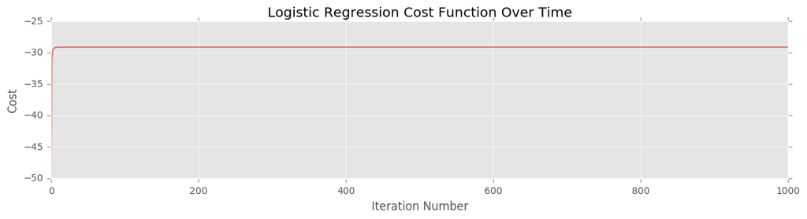

```python
fig, ax = plt.subplots(1, figsize=(14, 3))

plot_cost(cost_history, ax)
```

## Gradient Descent - implemented in OOP

### Put together all the functions we have written

```python
import numpy as np

def predict_proba(X, coeffs):
    '''
    INPUT: 2 dimensional numpy array, numpy array
    OUTPUT: numpy array

    Calculate the predicted percentages (floats between 0 and 1) for the given
    data with the given coefficients.
    '''
    pass
    linear_predictor = np.dot(X, coeffs)
    denom = 1 + np.exp(-linear_predictor)
    return 1.0 / denom

def predict(X, coeffs, thres=0.5):
    '''
    INPUT: 2 dimensional numpy array, numpy array
    OUTPUT: numpy array

    Calculate the predicted values (0 or 1) for the given data with the given
    coefficients.
    '''
    pass
    probs = predict_proba(X, coeffs)
    return (probs >= thres).astype(int)

def log_likelihood(X, y, coeffs):
    '''
    INPUT: 2 dimensional numpy array, numpy array, numpy array
    OUTPUT: float

    Calculate the log likelihood of the data with the given coefficients.
    '''

    p = predict_proba(X, coeffs)
    cost_per_observation = y * np.log(p) + (1 - y) * np.log(1 - p)
    return np.sum(cost_per_observation)

def log_likelihood_gradient(X, y, coeffs):
    '''
    INPUT: 2 dimensional numpy array, numpy array, numpy array
    OUTPUT: numpy array

    Calculate the gradient of the log likelihood at the given value for the
    coeffs. Return an array of the same size as the coeffs array.
    '''
    p = predict_proba(X, coeffs)
    gradient = X.T.dot(y - p)
    return gradient
```

### Write a Gradient Ascent class

- It will use functions defined for logistic regression:
  - cost function
  - gradient
  - prediction function

```python
import numpy as np

class GradientAscent(object):

    def __init__(self, cost, gradient, predict_func, fit_intercept=False):
        '''
        INPUT: GradientAscent, function, function, function, boolean
        OUTPUT: None

        Initialize class variables.
        Three input functions:
            cost: the cost function to be minimized
            gradient: function to calculate the gradient of the cost function
            predict_func: function to calculate the predictions
        One boolean argument:
            fit_intercept: boolean flag to determine whether estimate the intercept/bias
        '''
        # Initialize coefficients in run method once you know how many features you have
        self.coeffs = None
        self.cost = cost
        self.gradient = gradient
        self.predict_func = predict_func
        self.fit_intercept = fit_intercept

    def run(self, X, y, alpha=0.1, num_iterations=1000):
        '''
        INPUT: GradientAscent, 2 dimensional numpy array, numpy array
               float, int
        OUTPUT: None

        Run the gradient ascent algorithm for num_iterations repititions. Use
        the gradient method and the learning rate alpha to update the
        coefficients at each iteration.
        '''
        ## add intercept (if we want to)
        if self.fit_intercept:
            X = self.add_intercept(X)

        ## Initialize coeffs to all zeros
        self.coeffs = np.zeros(X.shape[1])

        self.cost_history = []
        for i in xrange(num_iterations):
            grad = self.gradient(X, y, self.coeffs)
            self.coeffs = self.coeffs + alpha * grad
            cost = self.cost(X, y, self.coeffs)
            self.cost_history.append(cost)

    def predict(self, X):
        '''
        INPUT: GradientAscent, 2 dimensional numpy array
        OUTPUT: numpy array (ints)

        Use the coeffs to compute the prediction for X. Return an array of 0's
        and 1's.
        '''
        if self.fit_intercept:
            X = self.add_intercept(X)
        return self.predict_func(X, self.coeffs)

    def add_intercept(self, X):
        '''
        INPUT: 2 dimensional numpy array
        OUTPUT: 2 dimensional numpy array

        Return a new 2d array with a column of ones added as the first
        column of X.
        '''
        return np.hstack((np.ones((X.shape[0], 1)), X))
```

```python
ga = GradientAscent(cost=log_likelihood,
                    gradient=log_likelihood_gradient,
                    predict_func=predict,
                    fit_intercept=False)
```

```python
ga.run(X, y, alpha=0.1, num_iterations=1000)
```

```python
y_pred = ga.predict(X)
coeffs = ga.coeffs
gradient = ga.gradient(X, y_pred, coeffs)
print("The predicted class vector is \n{}".format(str(y_pred)))
print("The actual class vector is \n{}".format(str(y)))
```

```
The predicted class vector is
[0 0 0 1 1 1 0 0 0 0 0 1 0 0 0 1 0 0 0 0 0 1 1 1 1 0 1 1 0 0 1 0 1 0 1 1 0
 1 1 1 0 1 0 0 0 1 1 0 1 0 0 0 1 0 0 0 0 1 0 1 1 0 0 1 1 0 0 1 0 0 0 1 1 0
 1 0 1 1 0 0 1 0 1 0 0 1 1 0 0 1 0 1 1 0 1 0 0 1 0 0]
The actual class vector is
[0 0 0 1 1 1 0 0 1 1 0 1 0 0 0 1 0 0 0 0 1 1 1 1 1 0 1 1 0 1 1 0 1 0 1 0 0
 1 1 1 0 1 0 1 0 1 1 0 1 0 0 1 1 0 0 0 0 1 0 0 1 0 0 1 1 0 0 1 0 1 0 1 1 0
 1 0 1 1 0 1 1 0 1 0 0 1 1 0 1 1 0 1 1 0 1 0 0 1 0 0]
```

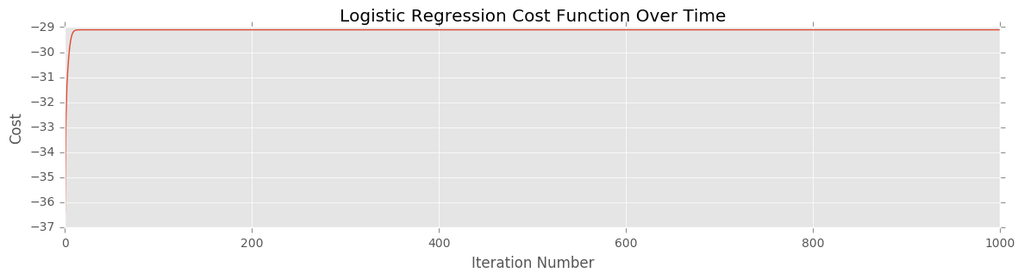

```python
fig, ax = plt.subplots(1, figsize=(14, 3))

plot_cost(ga.cost_history, ax)
```

### Metrics

Cost value is not very good to interprete the result. We need more meaning metrics

```python
def accuracy(y_true, y_pred):
    '''
    INPUT: numpy array, numpy array
    OUPUT: float

    Calculate the percent of predictions which equal the true values.
    '''
    return float(np.sum(y_true == y_pred)) / len(y_true)

def precision(y_true, y_pred):
    '''
    INPUT: numpy array, numpy array
    OUTPUT: float

    Calculate the percent of positive predictions which were correct.
    '''
    return float(np.sum(y_true * y_pred)) / np.sum(y_pred)

def recall(y_true, y_pred):
    '''
    INPUT: numpy array, numpy array
    OUTPUT: float

    Calculate the percent of positive cases which were correctly predicted.
    '''
    return float(np.sum(y_true * y_pred)) / np.sum(y_true)
```

```python
print("Accuracy of the Logistic Regression is: {}".format(accuracy(y, y_pred)))
print("Precision of the Logistic Regression is: {}".format(precision(y, y_pred)))
print("Recall of the Logistic Regression is: {}".format(recall(y, y_pred)))
```

```
Accuracy of the Logistic Regression is: 0.89
Precision of the Logistic Regression is: 0.953488372093
Recall of the Logistic Regression is: 0.82
```

Looks good!

### Visualize the Fitted Model

Now that the model has been fit, we can see the estimated coefficients and the final predictions on the training data.

```python
print("Estimated Logistic Coefficients: {}".format(str(ga.coeffs)))
print("Predicted Values on Training Data: {}".format(str(ga.predict(X)[:5])))
```

```
Estimated Logistic Coefficients: [ 2.70706753  0.61488544]
Predicted Values on Training Data: [0 0 0 1 1]
```

The coefficients returned from the gradient ascent are *not* the `m` and `b` from our earlier eyeball exercise. Indeed, we have *not* yet included an intercept term in our model, so this coefficient vector really only encodes `m`.

So why two parameters?

Well, the coefficients here encode *two* pieces of information:

- The slope of the decision boundary.
- How rapidly the predicted probability changes as we move away from the decision boundary.

More precisely, the coefficient vector is *orthogonal* to the decision boundary, and it's length encodes the rate of change of the predicted probabilities.

To find the actual equation of the decision boundary, recall its definition:

$$ h(x) = 0.5 $$

The $h$ here is the logistic function that converts the linear part of the model into probabilities:

$$ h(x) = \frac{1}{1 + e^{-x}} $$

Recall that the *inverse* of the logistic function is the log odds:

$$ h^{-1}(p) = \log \left( \frac{p}{1-p} \right) $$

So, applying the inverse on both sides to the decision boundary equation yields:

$$ \beta_0 x_0 + \beta_1 x_1 = \log \left( \frac{0.5}{1 - 0.5} \right) = 0 $$

Or, rearranging, the equation of the decision boundary is:

$$ x_1 = - \frac{\beta_0}{\beta_1} x_0 $$

Let's plot the fit decision boundary along with our eyeballed attempt.

```python
def plot_decision_boundary_no_intercept(X, coeffs, ax):
    """Plot the decision boundary from a logistic regression that does
    not contain an intercept term.
    """
    x0_bounds, x1_bounds = compute_scatterplot_bounds(X)
    t = np.linspace(x0_bounds[0], x0_bounds[1], num=3)
    m = - coeffs[0] / coeffs[1]
    ax.plot(t, m*t, label="Logistic Regression Line")
```

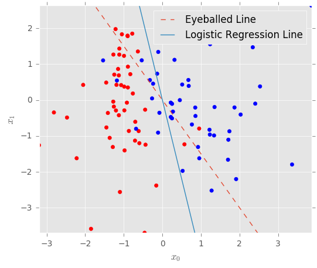

```python
fig, ax = plt.subplots(1, figsize=(6, 5))

plot_classification_data(X, y, ax)
plot_eyeballed_line_no_intercept(X, ax)
plot_decision_boundary_no_intercept(X, ga.coeffs, ax)
ax.legend()
```

Notice that *both* lines go through $(0, 0)$, as they should. Our eyeballed line is clearly worse than the decision boundary returned from logistic regression, as it *must* be (or at least, we should be able to do *no better* than logistic regression).

## Compare with sklearn

We can fit `sklearn`'s `LogisticRegression` to the same data, and check that we get the same parameter estimates. A couple things to note here:

- The `LogisticRegression` model from `sklearn` includes regularization. We set the `C` parameter very large to turn it off.
- It also includes an intercept by default, there is an option to turn this off.

```python
from sklearn.linear_model import LogisticRegression
lr = LogisticRegression(C=10**6, fit_intercept=False)
lr.fit(X, y)
```

```
LogisticRegression(C=1000000, class_weight=None, dual=False,
          fit_intercept=False, intercept_scaling=1, max_iter=100,
          multi_class='ovr', n_jobs=1, penalty='l2', random_state=None,
          solver='liblinear', tol=0.0001, verbose=0, warm_start=False)
```

```python
print("Gradient Descent Coefficients: {}".format(ga.coeffs))
print("LogisticRegression Coefficents: {}".format(lr.coef_))
```

```
Gradient Descent Coefficients: [ 2.70706753  0.61488544]
LogisticRegression Coefficents: [[ 2.70635687  0.61461823]]
```

**Note:** The algorithms used in these two approaches are *not the same*. We use gradient ascent, but sklearn uses a linear algebra library intended for fittign support vector machines.

## Add Intercept

```python
ga_intercept = GradientAscent(cost=log_likelihood,
                              gradient=log_likelihood_gradient,
                              predict_func=predict,
                              fit_intercept=True)
```

```python
ga_intercept.run(X, y, num_iterations=200)
```

```python
y_pred = ga_intercept.predict(X)

print("The predicted class vector is \n{}".format(str(y_pred)))
print("The actual class vector is \n{}".format(str(y)))
```

```
The predicted class vector is
[0 0 0 1 1 1 0 0 0 1 0 1 0 0 0 1 0 0 0 0 0 1 1 1 1 0 1 1 0 0 1 0 1 0 1 1 0
 1 1 1 0 1 0 1 0 1 1 0 1 0 0 1 1 0 0 0 0 1 0 1 1 0 0 1 1 0 0 1 0 0 0 1 1 0
 1 0 1 1 0 0 1 0 1 0 0 1 1 0 1 1 0 1 1 0 1 0 0 1 0 0]
The actual class vector is
[0 0 0 1 1 1 0 0 1 1 0 1 0 0 0 1 0 0 0 0 1 1 1 1 1 0 1 1 0 1 1 0 1 0 1 0 0
 1 1 1 0 1 0 1 0 1 1 0 1 0 0 1 1 0 0 0 0 1 0 0 1 0 0 1 1 0 0 1 0 1 0 1 1 0
 1 0 1 1 0 1 1 0 1 0 0 1 1 0 1 1 0 1 1 0 1 0 0 1 0 0]
```

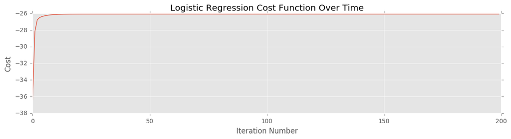

```python
fig, ax = plt.subplots(1, figsize=(14, 3))

plot_cost(ga_intercept.cost_history, ax)
```

```python
print("Estimated Logistic Coefficients: {}".format(str(ga_intercept.coeffs)))
print("Predicted Values on Training Data: {}".format(str(ga_intercept.predict(X)[:5])))
```

```
Estimated Logistic Coefficients: [ 0.99809371  3.35588318  0.70223695]
Predicted Values on Training Data: [0 0 0 1 1]
```

Notice that now we have *three* parameter estimates, the first is the intercept term.

We must go through the arithmetic again to derive the form of the decision boundary, but this time I will spare the details. The correct expression is:

$$ x_2 = - \frac{\beta_0}{\beta_2} - \frac{\beta_1}{\beta_2} x_1 $$

```python
def plot_decision_boundary(X, coeffs, ax, extra_label=''):
    """Plot the decision boundary from a logistic regression that
    includes an intercept as the first parameter.
    """
    x0_bounds, x1_bounds = compute_scatterplot_bounds(X)
    t = np.linspace(x0_bounds[0], x0_bounds[1], num=3)
    m = - coeffs[1] / coeffs[2]
    b = - coeffs[0] / coeffs[2]
    ax.plot(t, m * t + b, label="Logistic Regression Line {}".format(extra_label))
    set_scatterplot_bounds(x0_bounds, x1_bounds, ax)
```

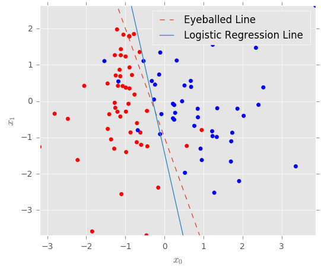

```python
fig, ax = plt.subplots(1, figsize=(6, 5))

plot_classification_data(X, y, ax)
plot_eyeballed_line(X, ax)
plot_decision_boundary(X, ga_intercept.coeffs, ax)
ax.legend()
```

We actually did pretty good here with our straightedge and eyeball method! Even so, a close examination does show the logistic regression line to be superior.

```python
y_pred = ga_intercept.predict(X)

print("Accuracy of the Logistic Regression is: {}".format(accuracy(y, y_pred)))
print("Precision of the Logistic Regression is: {}".format(precision(y, y_pred)))
print("Recall of the Logistic Regression is: {}".format(recall(y, y_pred)))
```

```
Accuracy of the Logistic Regression is: 0.93
Precision of the Logistic Regression is: 0.957446808511
Recall of the Logistic Regression is: 0.9
```

## Interpret the Coefficients

### Odds Ratio

The *odds ratio* measures the odds of being in the positive class compared to the odds of being in the negative class. It's computed like this:

[figure not shown]

Vice versa, we can calculate the probability based on the odds ratio:

[figure not shown]

Odds are comonly used in gambling, especially horse racing. Here's some examples to get a sense of the value:

[output not shown]

We can rearrange the equation for *p* a bit (divide numerator and denominator by *OR*).

[figure not shown]

Let's actually look at the log of the odds ratio (this will make sense in a second). The *log odds ratio* is as follows:

[figure not shown]

Now we can look at what *p* is in terms of the *log odds ratio*.

[figure not shown]

If we compare this to our sigmoid function from above, we see that *t = LOR*!

### Interpreting the Beta coefficients

While it's not as simple in logistic regression to interpret the coefficients as it is in linear regression, we can use the odds ratio to do a nice interpration.

As we noted above, the following are true:

[figure not shown]

Let's look at how increasing $x_i$ by 1 changes the log odds ratio. (This is the same as our interpretation in Linear Regression).

[figure not shown]

Now let's look at how it affects the Odds Ratio.

[figure not shown]

So now we can say the following:

*Increasing the value of $x_i$ by 1 increases the odds ratio by a factor of $e^{\beta_i}$*

```python
ga_intercept.coeffs
```

```
array([ 0.99809371,  3.35588318,  0.70223695])
```

```python
def bar_plot_coeffs(coeffs, ax, extra_label=''):
    """Bar plot the coefficients from a logistic regression.
    """
    t = np.arange(coeffs.shape[0])
    xtick = [r"$\beta_{}$".format(i) for i in t]
    ax.bar(t, coeffs, align="center")
    ax.set_title("Coefficients of Logistic Regression")
    ax.set_xticks(t)
    ax.set_xticklabels(xtick)
```

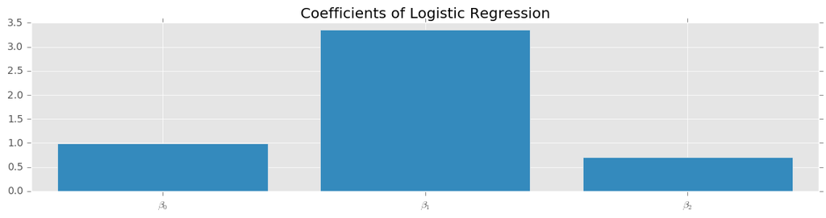

```python
fig, ax = plt.subplots(1, figsize=(14, 3))
bar_plot_coeffs(ga_intercept.coeffs, ax)
```

### Resources

- [Andrew Ng's Lecture Notes](http://cs229.stanford.edu/notes/cs229-notes1.pdf)
- [Gradient Descent Animation](http://vis.supstat.com/2013/03/gradient-descent-algorithm-with-r/)